# LS.1.5 Report - Extras

## 1a. Plot of 3 or 5 archetypal growth curves.

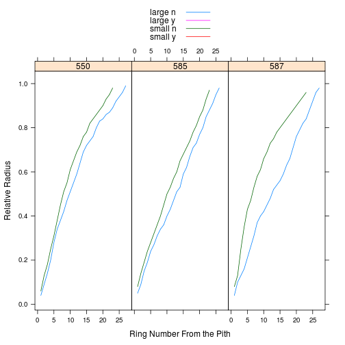

```r
library(lattice)
library(RODBC)
ch = odbcConnect("LS15")
R = sqlQuery(ch, "\n          select \n            LogEndImages.filename,\n            Forest,\n            logs.ScionLogNumber,\n            LogEndImages.logEnd,\n            inWhorl,\n            ring, \n            r\n          from \n            logs, \n            LogEndRings, \n            LogEndImages\n          where \n            LogEndRings.filename=LogEndImages.filename \n            and LogEndImages.ScionLogNumber=logs.ScionLogNumber\n             ")
xyplot(r ~ ring | as.factor(ScionLogNumber), R, group = paste(logEnd, inWhorl),
    type = "l", auto.key = list(points = FALSE, lines = TRUE), xlab = "Ring Number From the Pith",
    ylab = "Relative Radius", subset = inWhorl == "n" & ScionLogNumber %in%
        c(585, 550, 587), layout = c(3, 1, 1))
```

```r
load("~/Desktop/Dropbox/LS15/log-v-lumber/logs.RData")
```

Ring positions were manually digitzed in the yard log end imagery at a single point on the circumference. Limitations imposed by the nature of the log end surfaces, the presence of knots and the quality of the imagery introduce a degree of noise, and on occasion incredible results (e.g. more rings at the small end than at the large). The figure above plots relative growth trajectories for three typical logs. Growth trajectories at both log ends are shown, with both ends free of knots. For the most part the large and small ends show similar patterns. Classes of growth trajectory can be identified:

1. Growth rate constant through time at both ends (e.g. 585)
2. Growth rate decreasing through time at both ends (e.g. 550)
3. Growth trajectories differing between ends (e,g, 587)

## 1b. Is ring10volfrac equal to heartVolFrac?

The next plot compares heartwood area fraction with the area fraction occupied by material from pith to ring 10 for each log end. The datapoints are colored according to whether or not the log end contains knots. While the two measures are significantly (but not strongly) correlated, they are not synonymous. It is interesting to note that log ends containing knots, and consequently for which the boundary of ring 10 from the pith is ususally very disturbed, do not stand out.

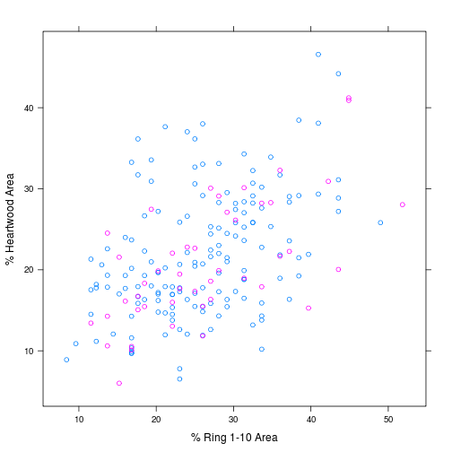

```r
ch = odbcConnect("LS15")
E = sqlQuery(ch, "\n          select \n             LogEndDigitizations.*,\n            LogEndImages.filename,\n            Forest,\n            logs.ScionLogNumber,\n            LogEndImages.logEnd,\n            inWhorl,\n             Aheart_mm2/A_mm2 as heartAreaFrac\n          from \n            logs, \n            LogEndDigitizations, \n            LogEndImages\n          where \n            LogEndDigitizations.filename=LogEndImages.filename \n            and LogEndImages.ScionLogNumber=logs.ScionLogNumber\n             and LogEndImages.imageType='yard'\n             and mm_per_pixel is not null")

xyplot(heartAreaFrac * 100 ~ ring10AreaFrac * 100, group = inWhorl, E, ylab = "% Heartwood Area",
    xlab = "% Ring 1-10 Area")
```

```r
summary(lm(heartAreaFrac ~ ring10AreaFrac, E))
```

```
##
## Call:
## lm(formula = heartAreaFrac ~ ring10AreaFrac, data = E)
##
## Residuals:
##     Min      1Q  Median      3Q     Max
## -0.1477 -0.0491 -0.0050  0.0381  0.1841
##
## Coefficients:
##                Estimate Std. Error t value Pr(>|t|)
## (Intercept)      0.1028     0.0153    6.73  1.8e-10 ***
## ring10AreaFrac   0.4367     0.0557    7.83  2.8e-13 ***
## ---
## Signif. codes:  0 '***' 0.001 '**' 0.01 '*' 0.05 '.' 0.1 ' ' 1
##
## Residual standard error: 0.0675 on 198 degrees of freedom
## Multiple R-squared:  0.237,  Adjusted R-squared:  0.233
## F-statistic: 61.4 on 1 and 198 DF,  p-value: 2.81e-13
```

## 2. A&E vs yard digitizations to demonstrate that pick out = dryness (554-556). Some words to the same effect.

```r
ch = odbcConnect("LS15")
P = sqlQuery(ch, "select * from LogEndDigitizations as d, LogEndDigitizationEdges as e, LogEndDigitizationPoints as p where d.id=e.digitizationID and e.id=p.edgeID and type<>'pith'")
```

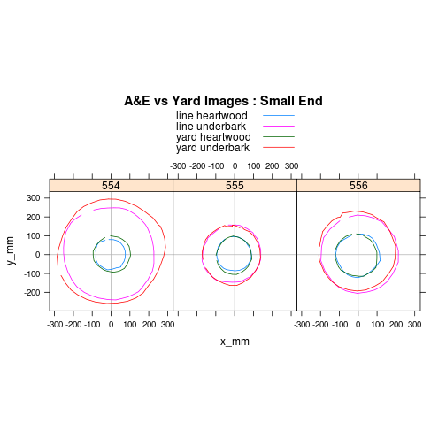

```r
myxyplot = function(x, y, ...) {
    panel.abline(h = 0, col = "grey70")
    panel.abline(v = 0, col = "grey70")
    panel.xyplot(x, y, ...)
}
xyplot(y_mm ~ x_mm | as.factor(ScionLogNumber), group = paste(imageType, type),
    P, auto.key = list(lines = TRUE, points = FALSE), type = "l", subset = logEnd ==
        "small" & ScionLogNumber %in% c(554, 555, 556), layout = c(3, 1, 1),
    aspect = "iso", panel = myxyplot, main = "A&E vs Yard Images : Small End")
```

The figure above compares, for three typical log small ends, the boundary of the heartwood zone identified in the yard log end imagery with the boundary of the pick-out' zone seen in the A&E images. While the match is not perfect, there is substantial correspondence between the heart/sap boundary, suggesting that 'pick-out' happens when lumen water has been lost, perhaps due to changes in wood-saw friction.

## 3. Meas vs predicted of a linear model for abc(swv, log dia, heart%).

```r
m.abc = lm(abc.bavg ~ swv.calibre + SED + heartVolFrac + ring10VolFrac, L)
summary(m.abc)
```

```
##
## Call:
## lm(formula = abc.bavg ~ swv.calibre + SED + heartVolFrac + ring10VolFrac,
##     data = L)
##
## Residuals:
##    Min     1Q Median     3Q    Max
## -2.171 -0.743 -0.204  0.492  5.947
##
## Coefficients:
##                Estimate Std. Error t value Pr(>|t|)
## (Intercept)   25.893558   3.436082    7.54  2.8e-11 ***
## swv.calibre   -0.005417   0.000805   -6.73  1.3e-09 ***
## SED           -0.012198   0.003078   -3.96  0.00014 ***
## heartVolFrac   6.239887   2.241777    2.78  0.00649 **
## ring10VolFrac -1.136503   2.916566   -0.39  0.69765
## ---
## Signif. codes:  0 '***' 0.001 '**' 0.01 '*' 0.05 '.' 0.1 ' ' 1
##
## Residual standard error: 1.32 on 95 degrees of freedom
## Multiple R-squared:  0.36,   Adjusted R-squared:  0.334
## F-statistic: 13.4 on 4 and 95 DF,  p-value: 1.09e-08
```

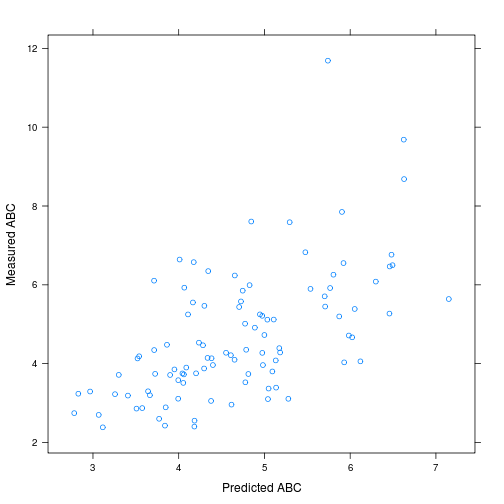

```r
xyplot(L$abc.bavg ~ predict(m.abc), xlab = "Predicted ABC", ylab = "Measured ABC")
```

## 4. recompute R based on centre of low stiffness boards (c.f. pith)

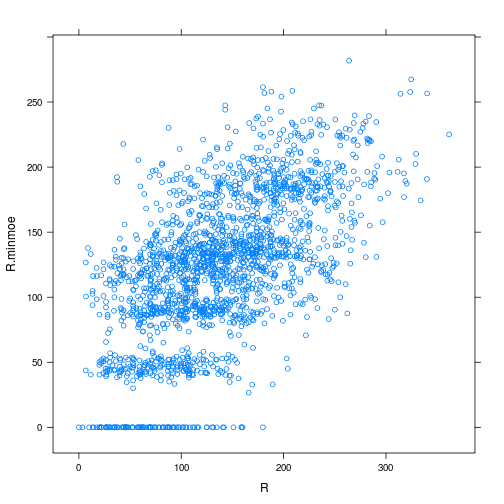

```r
# in each log find the least stiff board. Shift the origin to tha board's
# centre
for (ilog in 1:nrow(L)) {
    ii = c(1:nrow(BJ))[BJ$ScionLogNumber == L[ilog, "ScionLogNumber"]]
    pith.board = ii[order(BJ$moe[ii])][1]
    BJ[ii, "x.minmoe"] = BJ[ii, "x"] - BJ[pith.board, "x"]
    BJ[ii, "y.minmoe"] = BJ[ii, "y"] - BJ[pith.board, "y"]
}
BJ$R.minmoe = sqrt(BJ$x.minmoe^2 + BJ$y.minmoe^2)
xyplot(R.minmoe ~ R, BJ)
```

Is R.minmoe any better a predictor of twist?

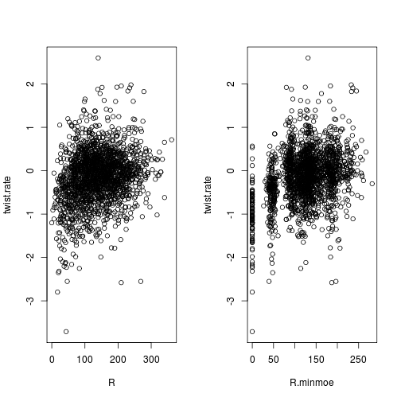

```r
par(mfcol = c(1, 2))
plot(twist.rate ~ R, BJ)
plot(twist.rate ~ R.minmoe, BJ)
```

```r
summary(lm(twist.rate ~ I(1/jitter(R)) + I(1/jitter(R.minmoe)), BJ))
```

```
##
## Call:
## lm(formula = twist.rate ~ I(1/jitter(R)) + I(1/jitter(R.minmoe)),
##     data = BJ)
##
## Residuals:
##    Min     1Q Median     3Q    Max
## -3.563 -0.326  0.035  0.353  2.747
##
## Coefficients:
##                        Estimate Std. Error t value Pr(>|t|)
## (Intercept)           -1.46e-01   1.37e-02  -10.66   <2e-16 ***
## I(1/jitter(R))        -1.68e-02   9.15e-03   -1.83    0.067 .
## I(1/jitter(R.minmoe)) -9.59e-07   2.04e-05   -0.05    0.963
## ---
## Signif. codes:  0 '***' 0.001 '**' 0.01 '*' 0.05 '.' 0.1 ' ' 1
##
## Residual standard error: 0.603 on 1936 degrees of freedom
##   (10 observations deleted due to missingness)
## Multiple R-squared:  0.00173,    Adjusted R-squared:  0.000697
## F-statistic: 1.68 on 2 and 1936 DF,  p-value: 0.187
```

## 5. Add comment re inner v outer v total give similar models

```r
lm2col = function(m, colname) {
    s = summary(m)
    a = s$coefficients[, 1]
    a["r.squared"] = s$r.squared
    a["RMSE"] = sqrt(mean(s$residuals^2, na.rm = TRUE))
    df = data.frame(a)
    names(df) <- c(colname)
    return(df)
}
T = lm2col(lm(moe.bavg ~ swv.calibre + SED + heartVolFrac + ring10VolFrac, L),
    "moe.all")
T = cbind(T, lm2col(lm(moe.Inner.bavg ~ swv.calibre + SED + heartVolFrac + ring10VolFrac,
    L), "moe.inner"))
T = cbind(T, lm2col(lm(moe.Outer.bavg ~ swv.calibre + SED + heartVolFrac + ring10VolFrac,
    L), "moe.outer"))
T = cbind(T, lm2col(lm(abc.bavg ~ swv.calibre + SED + heartVolFrac + ring10VolFrac,
    L), "abc.all"))
T = cbind(T, lm2col(lm(abc.Inner.bavg ~ swv.calibre + SED + heartVolFrac + ring10VolFrac,
    L), "abc.inner"))
T = cbind(T, lm2col(lm(abc.Outer.bavg ~ swv.calibre + SED + heartVolFrac + ring10VolFrac,
    L), "abc.outer"))
library(pander)
pander(T, split.tables = Inf)
```

|  | moe.all | moe.inner | moe.outer | abc.all | abc.inner | abc.outer |
| --- | --- | --- | --- | --- | --- | --- |
| **(Intercept)** | -9.846 | -6.692 | -9.84 | 25.89 | 23.47 | 28.07 |
| **swv.calibre** | 0.006449 | 0.005855 | 0.007425 | -0.005417 | -0.004603 | -0.006599 |
| **SED** | 0.003721 | -0.0006842 | -0.003291 | -0.0122 | -0.01187 | -0.008432 |
| **heartVolFrac** | -7.909 | -7.435 | -10.93 | 6.24 | 3.559 | 8.084 |
| **ring10VolFrac** | -3.737 | -4.708 | 3.036 | -1.137 | 0.2779 | -3.774 |
| **r.squared** | 0.8001 | 0.7429 | 0.6267 | 0.3604 | 0.3004 | 0.2009 |
| **RMSE** | 0.5837 | 0.6659 | 1.109 | 1.287 | 1.309 | 2.225 |

Models for the average board stiffness or ABC for all boards, the inner boards only and the outer boards only, while they differ considerably in their coeffcicients, are similar in their predictive abilities (RMSE, *r*<sup>2</sup>) as evident in the table above.

## 6. Add conclusion re current set of metrics being cheap, easy, familiar and lousy but not close to potential if (i) better raw data, (ii) better metric extraction, (iii) better metric conception

In the current study, the set of shape metrics extracted from the raw scan data have been selected based on previous experience and familiarity. They are cheap to compute and relatively easy to interpret, but should not be considered to be the 'best' possible shape-based predictors. There are numerous opportuinites for collecting better raw shape data (higher resolution, more precision), devising different descriptors and computing them more stably.

## 7. Rerun auto-correlation for stem velocity (based on avgLogSWV)

```r
library(RODBC)
ch = odbcConnect("KPPSWI", uid = "sa", pwd = "password12")
S = sqlQuery(ch, "select * from stems where recFrac>0.85 and avgLogSWV is not null and DateAndTime>'2014-05-01' and Forest not like '%9999%' order by DateAndTime")
```

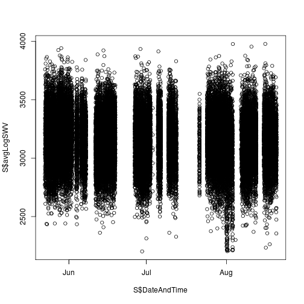

```r
plot(S$DateAndTime, S$avgLogSWV)
```

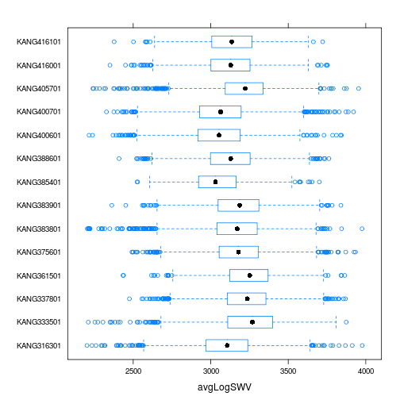

```r
forest.count = table(S$Forest)
many.log.forests = names(forest.count[forest.count > 1000])
bwplot(Forest ~ avgLogSWV, S, subset = Forest %in% many.log.forests)
```

```r
sed.class = cut(S$stemLED, seq(250, 750, by = 50))
table(sed.class)
```

```
## sed.class
## (250,300] (300,350] (350,400] (400,450] (450,500] (500,550] (550,600]
##       974      2780      5658      9295     10511     10142      7619
## (600,650] (650,700] (700,750]
##      4090      1529       409
```

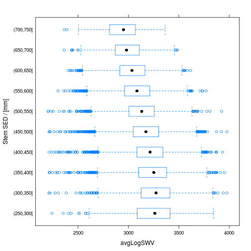

```r
bwplot(sed.class ~ avgLogSWV, S, ylab = "Stem SED / [mm]")
```

```r
Acf(S$avgLogSWV, type = "cor", demean = TRUE, lag.max = 250)
```

```
## Error: could not find function "Acf"
```

```r
Pacf(S$avgLogSWV, lag.max = 250)
```

```
## Error: could not find function "Pacf"
```

```r
# start with a linear model
summary(lm(avgLogSWV ~ stemLED, S))
```

```
##
## Call:
## lm(formula = avgLogSWV ~ stemLED, data = S)
##
## Residuals:
##     Min      1Q  Median      3Q     Max
## -1086.8  -125.0     6.2   133.8   808.5
##
## Coefficients:
##              Estimate Std. Error t value Pr(>|t|)
## (Intercept)  3.52e+03   4.50e+00   783.0   <2e-16 ***
## stemLED     -7.60e-01   9.07e-03   -83.8   <2e-16 ***
## ---
## Signif. codes:  0 '***' 0.001 '**' 0.01 '*' 0.05 '.' 0.1 ' ' 1
##
## Residual standard error: 195 on 53278 degrees of freedom
## Multiple R-squared:  0.116,  Adjusted R-squared:  0.116
## F-statistic: 7.02e+03 on 1 and 53278 DF,  p-value: <2e-16
```

```r
# lets look at this another way...
library(lme4)
(lmer(avgLogSWV ~ (1 | Forest:sed.class), S))
```

```
## Linear mixed model fit by REML ['lmerMod']
## Formula: avgLogSWV ~ (1 | Forest:sed.class)
##    Data: S
## REML criterion at convergence: 701912
## Random effects:
##  Groups           Name        Std.Dev.
##  Forest:sed.class (Intercept) 140
##  Residual                     180
## Number of obs: 53007, groups:  Forest:sed.class, 207
## Fixed Effects:
## (Intercept)
##        3128
```

```r
### time series analysis stuff...
library(forecast)
# https://www.otexts.org/fpp
# http://www.statmethods.net/advstats/timeseries.html
# http://www.stat.pitt.edu/stoffer/tsa3/tsa3EZ.pdf
# http://stat565.cwick.co.nz/lectures/07-estimation.pdf
# http://a-little-book-of-r-for-time-series.readthedocs.org/en/latest/src/timeseries.html
# http://www.stat.pitt.edu/stoffer/tsa3/R_toot.htm
(m.arima = auto.arima(S$avgLogSWV, max.p = 200, max.q = 50, seasonal = FALSE,
    stepwise = FALSE))
```

```
## Series: S$avgLogSWV
## ARIMA(2,1,3) with drift
##
## Coefficients:
```

```
##         ar1    ar2     ma1     ma2    ma3   drift
##       0.359  0.455  -1.263  -0.147  0.414  -0.002
## s.e.    NaN    NaN     NaN     NaN    NaN   0.016
##
## sigma^2 estimated as 40102:  log likelihood=-357951
## AIC=715916   AICc=715916   BIC=715978
```

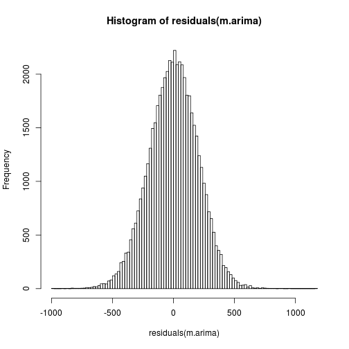

```r
hist(residuals(m.arima), 100)
```

```r
summary(arima(S$avgLogSWV, xreg = S$Forest, order = c(2, 1, 3)))
```

```
## Error: error in evaluating the argument 'object' in selecting a method for
## function 'summary': Error in lm.fit(x, y, offset = offset, singular.ok =
## singular.ok, ...) : 0 (non-NA) cases Calls: arima -> lm -> lm.fit
```

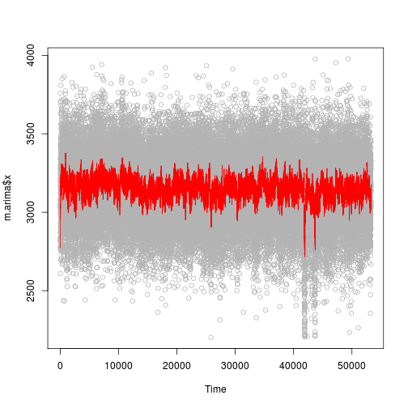

```r
plot(m.arima$x, type = "p", cex = 0.3, col = "grey70")
lines(m.arima$fitted, col = "red")
```

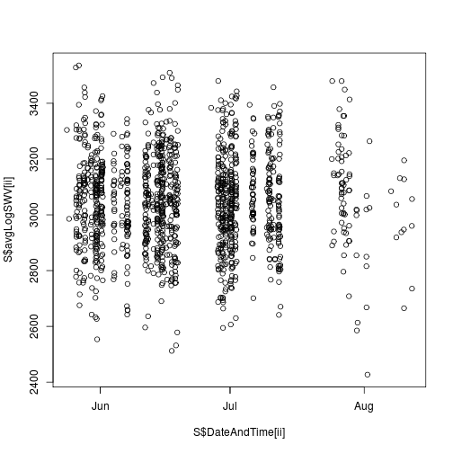

```r
# what if we confine our modelling to similar sized stems from the same
# forest?  KANG400701, (500,550] has the most data
ii = !is.na(S$Forest) & !is.na(sed.class) & S$Forest == " KANG400701 " & sed.class ==
    "(500,550]"
plot(S$DateAndTime[ii], S$avgLogSWV[ii])
```

```r
sum(ii)
```

```
## [1] 1380
```

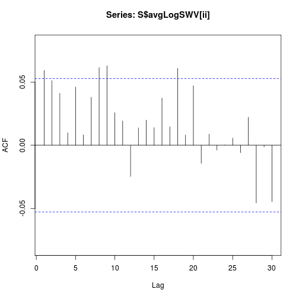

```r
Acf(S$avgLogSWV[ii])
```

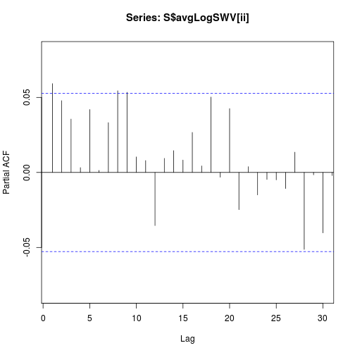

```r
Pacf(S$avgLogSWV[ii])
```

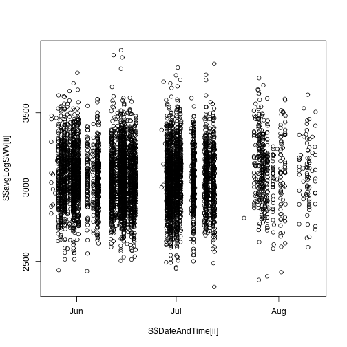

```r
# nothing in there at all

ii = !is.na(S$Forest) & S$Forest == " KANG400701 "
plot(S$DateAndTime[ii], S$avgLogSWV[ii])
```

```r
sum(ii)
```

```
## [1] 6470
```

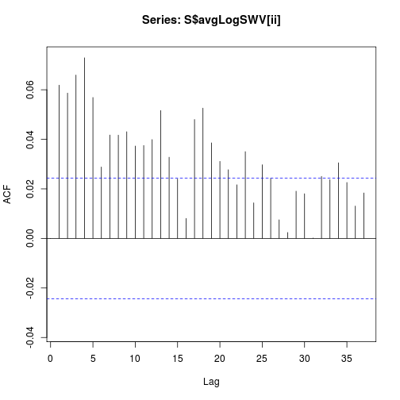

```r
Acf(S$avgLogSWV[ii])
```

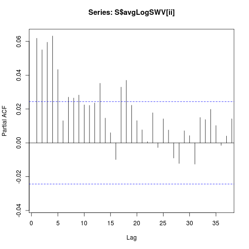

```r
Pacf(S$avgLogSWV[ii])
```

```r
sd(S$avgLogSWV)
```

```
## [1] 207.7
```

Means differ significantly between forests, but variance similar.

Stem SWV is influenced by diameter (LED), but again the effect is not strong.

Best ARIMA model reduces std error by only 7 m/s! (207 vs 200)

All of this suggests that the majority of variation in stem SWV is between individual stems.

Average log SWV can be used as a substitute for missing stem SWV, but the SWV of previously processed stems are poor predictors of the SWV of the current stem.

## 8. Table of TP vs FP for log stiffness and abc

How well can a linear model for average stiffness (moe) and warp (abc) serve to find the best or worst 10% of logs?

```r
m.moe = lm(moe.bavg ~ swv.calibre + SED + heartVolFrac + ring10VolFrac, L)
m.abc = lm(abc.bavg ~ swv.calibre + SED + heartVolFrac + ring10VolFrac, L)
roc = function(meas, pred) {
    TP = sum(pred & meas)
    TN = sum(!pred & !meas)
    FP = sum(pred & !meas)
    FN = sum(!pred & meas)
    return(list(TP = TP, TN = TN, FP = FP, FN = FN, TPR = TP/(TP + FN), FPR = FP/(TN +
        FP)))
}


m = L$moe.bavg  # measured
p = predict(m.moe)  # predicted
crit = quantile(p, 0.9)
R = roc(m > crit, p > crit)
T = data.frame(crit = crit, TPR = R[["TPR"]], FPR = R[["FPR"]], row.names = c("moe.best"))

crit = quantile(p, 0.1)
R = roc(m < crit, p < crit)
T = rbind(T, data.frame(crit = crit, TPR = R[["TPR"]], FPR = R[["FPR"]], row.names = c("moe.worst")))

m = L$abc.bavg  # measured
p = predict(m.abc)  # predicted
crit = quantile(p, 0.1)
R = roc(m < crit, p < crit)
T = rbind(T, data.frame(crit = crit, TPR = R[["TPR"]], FPR = R[["FPR"]], row.names = c("abc.best")))

crit = quantile(p, 0.9)
R = roc(m < crit, p < crit)
T = rbind(T, data.frame(crit = crit, TPR = R[["TPR"]], FPR = R[["FPR"]], row.names = c("abc.worst")))

pander(T, split.table = Inf, digits = 2)
```

|  | crit | TPR | FPR |
| --- | --- | --- | --- |
| **moe.best** | 11 | 0.59 | 0 |
| **moe.worst** | 7.9 | 0.67 | 0.044 |
| **abc.best** | 3.5 | 0.32 | 0.027 |
| **abc.worst** | 6 | 0.95 | 0.67 |

TPR: True Positive Rate. Ratio of logs that are predicted to meet the criteria compared to those that actually meet it. FPR: False Positive Rate. Ratio of logs that are predicted to not meet the criteria compared to those that actually do not meet it. Ideally TPR=1 and FPR=0. If FPR=TPR then the classifier is no better than random guessing.

The next plot presennts the so-called receiver operator curves for classification of best and worst logs using a linear model. These plots demonstrate the feasibility of finding elite logs (high stiffness and low warp), or of finding logs that will produce the least stiff lumber, but not of finding the worst logs for warp.

```r
library(ROCR)
```

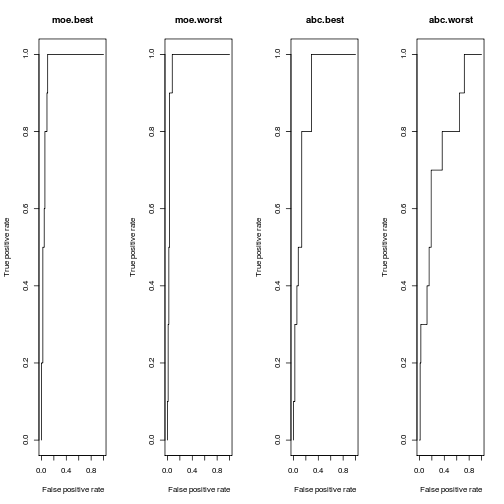

```r
par(mfcol = c(1, 4))
plot(performance(prediction(predict(m.moe), L$moe.bavg > quantile(L$moe.bavg,
    0.9)), "tpr", "fpr"), main = "moe.best")
plot(performance(prediction(-predict(m.moe), L$moe.bavg < quantile(L$moe.bavg,
    0.1)), "tpr", "fpr"), main = "moe.worst")
plot(performance(prediction(-predict(m.abc), L$abc.bavg < quantile(L$abc.bavg,
    0.1)), "tpr", "fpr"), main = "abc.best")
plot(performance(prediction(predict(m.abc), L$abc.bavg > quantile(L$abc.bavg,
    0.9)), "tpr", "fpr"), main = "abc.worst")
```

## 9. Scale sample logs to population using input metrics then tabulate: worst/best 5/10% of logs in sample = X% in pop. Only consider stiffness.

```r
library(RODBC)
ch = odbcConnect("KPPSWI", uid = "sa", pwd = "password12")
P = sqlQuery(ch, "select DateAndTime, velocity from Phase2 where velocity>2000 and velocity<4000 and StartPos<1000")
nrow(P)
```

```
## [1] 187628
```

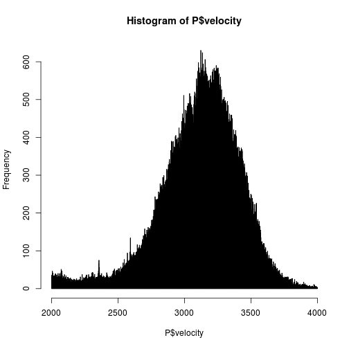

```r
hist(P$velocity, 1000)
```

```r
swv = sort(L$swv.calibre)
P$class = cut(P$velocity, breaks = c(-Inf, (swv[1:length(swv) - 1] + swv[2:length(swv)])/2,
    Inf), labels = L$ScionLogNumber[order(L$swv.calibre)])
table(P$class)
```

```
##
##    44    93    73    70    31    54     6    12     2    62    51    23
## 26038  2603  3548  1611  2710  4620  2515  1368  3479  2682  1999  1721
##    52    82    22    46    81    75    74    26    38    67    50     5
##   458  3368  2919   228  1830  2402  2886  2547   673  1579  2227  1715
##    68    28    17    18    11    91    65    66    86    34    61    83
##  2300  2714  1161     0   858  1912  2322  1713  1504  1422   562   274
##    29    43    88    16    92    60    10    90    85    72    37     4
##   812   868   268   566   297   605   572   547   312  1677  1385  1879
##    33    78     1    69    89    19    36    27    57    96    63    24
##  1872  1312  1088   563  1849  1099   546  1934  1661   255   823  1721
##    58    42     3    35   100    20    25    53    95    98    79    15
##  1443  1690  1359  1167   265   299  1048  1107     0  2405  2499   976
##    64    56    14    49    45    59    80    87    77     7    99    84
##  3425  3833   897  2301  3480  5855  4311  1264   690   518   733  1552
##    47    94    32    97    76    30     8    55    21    48    39    13
##  2475  1294   769   807  1331  2434  1310   443  2138  1784   778   854
##    71    41    40     9
##   752  1842  2639  3882
```

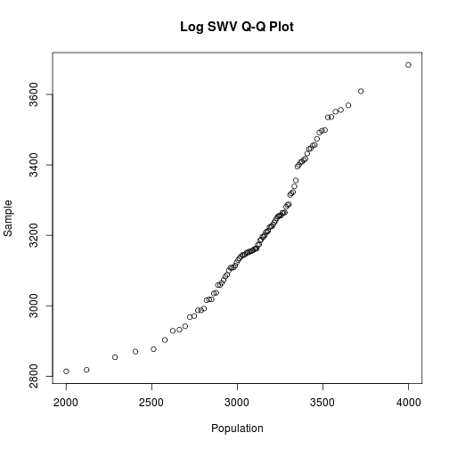

```r
out = qqplot(P$velocity, L$swv.calibre, ylab = "Sample", xlab = "Population",
    main = "Log SWV Q-Q Plot")
```

```r
F.s = ecdf(L$swv.calibre)
F.p = ecdf(P$velocity)
library(signal)
```

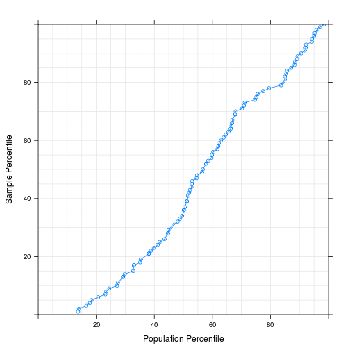

```r
xyplot(F.s(out[["y"]]) * 100 ~ interp1(out[["x"]], F.p(out[["x"]]), out[["y"]]) *
    100, aspect = "iso", panel = function(...) {
    panel.grid(h = 19, v = 19)
    panel.xyplot(...)
}, xlim = c(0, 100), ylim = c(0, 100), type = "b", xlab = "Population Percentile",
    ylab = "Sample Percentile")
```

```r
# same as above but based on a normal model for the population
# libaray(mixtools) fit=normalmixEM(P$velocity, k=3) # N(3153, 260.4)
# fit=normalmixEM(P$velocity, k=6) # N(3150, 256.5)
# fit=normalmixEM(P$velocity, k=2) # N(3165, 236.0) plot(fit, density=T)
# xyplot(F.s(out[['y']]) ~ interp1(out[['x']],pnorm(out[['x']],mean=3150,
# sd=256),out[['y']]), aspect='iso', panel=function(...) {
# panel.grid(h=19,v=19) panel.xyplot(...)},
# xlim=c(0,1),ylim=c(0,1),type='b') gives very similar results
```

At Hyne we want to avoid the skewed representation at the low stiffness end by not rushing the selection.